# hyperparameter-tuning

DATA IMPORT/ TIDY/ TRANSFORM

```r
#Library Loading:

library(tidyverse)
library(tidymodels)
library(powerjoin)
library(glue)
library(vip)
library(baguette)
library(readr)
```

```r
# Data Ingest:

download.file('https://gdex.ucar.edu/dataset/camels/file/camels_attributes_v2.0.pdf',
              'data/camels_attributes_v2.0.pdf')

root  <- 'https://gdex.ucar.edu/dataset/camels/file'

types <- c("clim", "geol", "soil", "topo", "vege", "hydro")

remote_files  <- glue('{root}/camels_{types}.txt')

local_files   <- glue('data/camels_{types}.txt')

walk2(remote_files, local_files, download.file, quiet = TRUE)

camels <- map(local_files, read_delim, show_col_types = FALSE)

camels <- power_full_join(camels ,by = 'gauge_id')
```

```r
# Data Cleaning:

drop_na(camels)
```

```
# A tibble: 507 × 58
   gauge_id p_mean pet_mean p_seasonality frac_snow aridity high_prec_freq
   <chr>     <dbl>    <dbl>         <dbl>     <dbl>   <dbl>          <dbl>
 1 01022500   3.61     2.12       -0.115      0.245   0.587           20.6
 2 01031500   3.52     2.07        0.104      0.292   0.588           18.9
 3 01047000   3.32     2.09        0.148      0.280   0.629           20.1
 4 01052500   3.73     2.10        0.152      0.353   0.562           13.5
 5 01054200   4.07     2.13        0.105      0.300   0.523           17.5
 6 01055000   3.49     2.09        0.167      0.306   0.599           19.2
 7 01057000   3.57     2.13        0.0791     0.251   0.597           20.4
 8 01073000   3.50     2.21        0.0304     0.175   0.630           20.8
 9 01078000   3.56     2.18        0.110      0.240   0.613           21.4
10 01118300   3.90     2.31       -0.0377     0.111   0.593           21.5
# ℹ 497 more rows
# ℹ 51 more variables: high_prec_dur <dbl>, high_prec_timing <chr>,
#   low_prec_freq <dbl>, low_prec_dur <dbl>, low_prec_timing <chr>,
#   geol_1st_class <chr>, glim_1st_class_frac <dbl>, geol_2nd_class <chr>,
#   glim_2nd_class_frac <dbl>, carbonate_rocks_frac <dbl>, geol_porostiy <dbl>,
#   geol_permeability <dbl>, soil_depth_pelletier <dbl>,
#   soil_depth_statsgo <dbl>, soil_porosity <dbl>, soil_conductivity <dbl>, …
```

```r
camels %>%
  mutate(logC = log(q_mean +1))
```

```
# A tibble: 671 × 59
   gauge_id p_mean pet_mean p_seasonality frac_snow aridity high_prec_freq
   <chr>     <dbl>    <dbl>         <dbl>     <dbl>   <dbl>          <dbl>
 1 01013500   3.13     1.97        0.188      0.313   0.631           13.0
 2 01022500   3.61     2.12       -0.115      0.245   0.587           20.6
 3 01030500   3.27     2.04        0.0474     0.277   0.624           17.2
 4 01031500   3.52     2.07        0.104      0.292   0.588           18.9
 5 01047000   3.32     2.09        0.148      0.280   0.629           20.1
 6 01052500   3.73     2.10        0.152      0.353   0.562           13.5
 7 01054200   4.07     2.13        0.105      0.300   0.523           17.5
 8 01055000   3.49     2.09        0.167      0.306   0.599           19.2
 9 01057000   3.57     2.13        0.0791     0.251   0.597           20.4
10 01073000   3.50     2.21        0.0304     0.175   0.630           20.8
# ℹ 661 more rows
# ℹ 52 more variables: high_prec_dur <dbl>, high_prec_timing <chr>,
#   low_prec_freq <dbl>, low_prec_dur <dbl>, low_prec_timing <chr>,
#   geol_1st_class <chr>, glim_1st_class_frac <dbl>, geol_2nd_class <chr>,
#   glim_2nd_class_frac <dbl>, carbonate_rocks_frac <dbl>, geol_porostiy <dbl>,
#   geol_permeability <dbl>, soil_depth_pelletier <dbl>,
#   soil_depth_statsgo <dbl>, soil_porosity <dbl>, soil_conductivity <dbl>, …
```

DATA SPLITTING

```r
# Initial Split
set.seed(123)

camels_split <- initial_split(camels, prop = 0.8)

#Training/ Testing
camels_train <- training(camels_split)
camels_test  <- testing(camels_split)
```

FEATURE ENGINEERING

```r
# Proper Recipe

rec <-  recipe(q_mean ~ ., data = camels_train) %>%
  step_rm(gauge_lat, gauge_lon, gauge_id, high_prec_timing, low_prec_timing, geol_1st_class, geol_2nd_class, dom_land_cover) %>%
  step_naomit(all_predictors(), all_outcomes())
```

DATA RESAMPLING AND MODEL TESTING

```r
# Cross Validation Data Set
camels_cv <- vfold_cv(camels_train, v = 10)
```

```r
# Define Three Regression Models

# Linear Regression
lm_model <- linear_reg() %>%
  set_engine("lm") %>%
  set_mode("regression")

# Random Forest Regression
rf_model <- rand_forest() %>%
  set_engine("ranger", importance = "impurity") %>%
  set_mode("regression")

#XG Boost
b_model <- boost_tree() |>
  set_engine("xgboost") |>
  set_mode("regression")
```

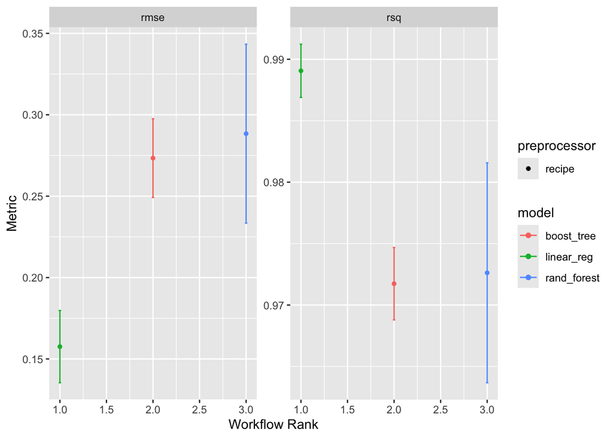

```r
# Workflow Set/ Map/ Autoplot

wf <- workflow_set(list(rec), list(b_model, rf_model, lm_model)) %>%
  workflow_map('fit_resamples', resamples = camels_cv)

autoplot(wf)
```

Model Selection With Justification:

I think the Linear Regression Model performs the best, because it has the highest r squared value out and the lowest root mean squared error out of all the data.

I am choosing the Linear Regression Model. It’s engine is “lm” and it’s in regression mode. I think that it’s performing well for this problem because it fundamentally measures the relationship between a dependent variable (q_mean) and an independent variable (all of the other variables,) and is commonly used in environmental science.

MODEL TUNING

```r
#Tunable Model Set Up:

#Even though linear regression had the best metrics, it wasn't working for the tuning, so I changed it to random forest and now it works.

library(tune)
#install.packages("bonsai")
library(bonsai)


rf_model_tune <- rand_forest(trees = tune(), min_n = tune()) |>
  set_engine("ranger") |>
  set_mode("regression")

# Tunable Workflow Defined:

wf_tune <- workflow() %>%
  add_model(rf_model_tune) %>%
  add_recipe(rec)

camels_metrics = metric_set(rsq, rmse, mae)

# Description of Dial Ranges:

dials <- extract_parameter_set_dials(wf_tune)
dials$object
```

```
# Trees (quantitative)
```

```
Range: [1, 2000]
```

```
Minimal Node Size (quantitative)
```

```
Range: [2, 40]
```

```r
# Define Search Space:

my.grid <- dials |>
  update(trees = trees(c(50, 500))) |>
  grid_latin_hypercube(size = 20)
range(my.grid$trees)
```

```
[1]  66 493
```

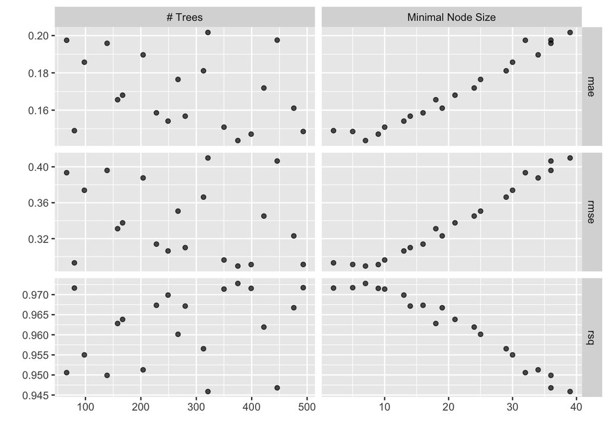

```r
# Tune the Model
model_params <-  tune_grid(
    wf_tune,
    resamples = camels_cv,
    grid = my.grid,
    metrics = metric_set(rmse, rsq, mae),
    control = control_grid(save_pred = TRUE)
  )

autoplot(model_params)
```

As the minimal node size increases, mean absolute error and root mean squared error increase while r squared decreases. Number of trees has no affect on any of the metrics, as the scatter plots are completely random.

CHECK SKILL OF TUNED MODEL

```r
# Collect Metrics

collect_metrics(model_params)
```

```
# A tibble: 60 × 8
   trees min_n .metric .estimator  mean     n std_err .config
   <int> <int> <chr>   <chr>      <dbl> <int>   <dbl> <chr>
 1   249    13 mae     standard   0.154    10 0.0121  Preprocessor1_Model01
 2   249    13 rmse    standard   0.306    10 0.0363  Preprocessor1_Model01
 3   249    13 rsq     standard   0.970    10 0.00533 Preprocessor1_Model01
 4   139    36 mae     standard   0.196    10 0.0157  Preprocessor1_Model02
 5   139    36 rmse    standard   0.396    10 0.0487  Preprocessor1_Model02
 6   139    36 rsq     standard   0.950    10 0.00800 Preprocessor1_Model02
 7    98    30 mae     standard   0.186    10 0.0145  Preprocessor1_Model03
 8    98    30 rmse    standard   0.374    10 0.0426  Preprocessor1_Model03
 9    98    30 rsq     standard   0.955    10 0.00633 Preprocessor1_Model03
10   158    18 mae     standard   0.166    10 0.0131  Preprocessor1_Model04
# ℹ 50 more rows
```

How do I arrange for descending values but keep all organized ??

```r
# Show Best

show_best(model_params, metric = "rsq")
```

```
# A tibble: 5 × 8
  trees min_n .metric .estimator  mean     n std_err .config
  <int> <int> <chr>   <chr>      <dbl> <int>   <dbl> <chr>
1   375     7 rsq     standard   0.973    10 0.00489 Preprocessor1_Model15
2   493     5 rsq     standard   0.972    10 0.00603 Preprocessor1_Model08
3    80     2 rsq     standard   0.972    10 0.00434 Preprocessor1_Model11
4   399     9 rsq     standard   0.972    10 0.00608 Preprocessor1_Model13
5   350    10 rsq     standard   0.971    10 0.00574 Preprocessor1_Model07
```

```r
show_best(model_params, metric = "rmse")
```

```
# A tibble: 5 × 8
  trees min_n .metric .estimator  mean     n std_err .config
  <int> <int> <chr>   <chr>      <dbl> <int>   <dbl> <chr>
1   375     7 rmse    standard   0.290    10  0.0327 Preprocessor1_Model15
2   399     9 rmse    standard   0.291    10  0.0351 Preprocessor1_Model13
3   493     5 rmse    standard   0.291    10  0.0334 Preprocessor1_Model08
4    80     2 rmse    standard   0.293    10  0.0304 Preprocessor1_Model11
5   350    10 rmse    standard   0.296    10  0.0329 Preprocessor1_Model07
```

```r
show_best(model_params, metric = "mae")
```

```
# A tibble: 5 × 8
  trees min_n .metric .estimator  mean     n std_err .config
  <int> <int> <chr>   <chr>      <dbl> <int>   <dbl> <chr>
1   375     7 mae     standard   0.144    10 0.00963 Preprocessor1_Model15
2   399     9 mae     standard   0.147    10 0.0106  Preprocessor1_Model13
3   493     5 mae     standard   0.149    10 0.00933 Preprocessor1_Model08
4    80     2 mae     standard   0.149    10 0.0110  Preprocessor1_Model11
5   350    10 mae     standard   0.151    10 0.0100  Preprocessor1_Model07
```

```r
# Select Best

hp_best <- select_best(model_params, metric = "rsq")
```

FINALIZE YOUR MODEL

```r
# Finalize Workflow

final_wf <- finalize_workflow(wf_tune, hp_best)
```

FINAL MODEL VERIFICATION

```r
# Implement Last Fit

final_fit <- last_fit(final_wf, camels_split, metrics = camels_metrics)

# Collect Metrics
collect_metrics(final_fit)
```

```
# A tibble: 3 × 4
  .metric .estimator .estimate .config
  <chr>   <chr>          <dbl> <chr>
1 rsq     standard       0.972 Preprocessor1_Model1
2 rmse    standard       0.287 Preprocessor1_Model1
3 mae     standard       0.124 Preprocessor1_Model1
```

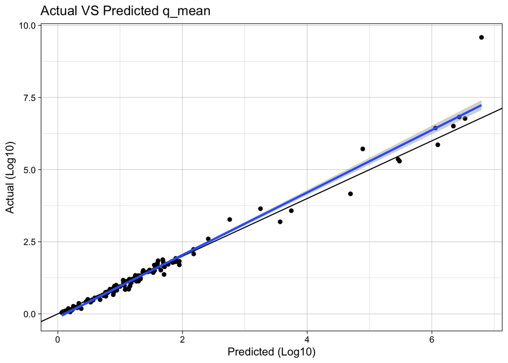

```r
# Collect Predictions

#Plots

collect_predictions(final_fit) |>
  ggplot(aes(x = .pred, y = q_mean)) +
  geom_point() +
  geom_abline() +
  geom_smooth(method = "lm") +
  theme_linedraw() +
  labs(title = "Actual VS Predicted q_mean",
       x = "Predicted (Log10)",
       y = "Actual (Log10)")
```

BUILDING A MAP

```r
library(patchwork)

final <- fit(final_wf, data = camels) %>%
  augment(new_data = camels) %>%
  mutate(residuals = .pred - q_mean)

names(final_fit)
```

```
[1] "splits"       "id"           ".metrics"     ".notes"       ".predictions"
[6] ".workflow"
```

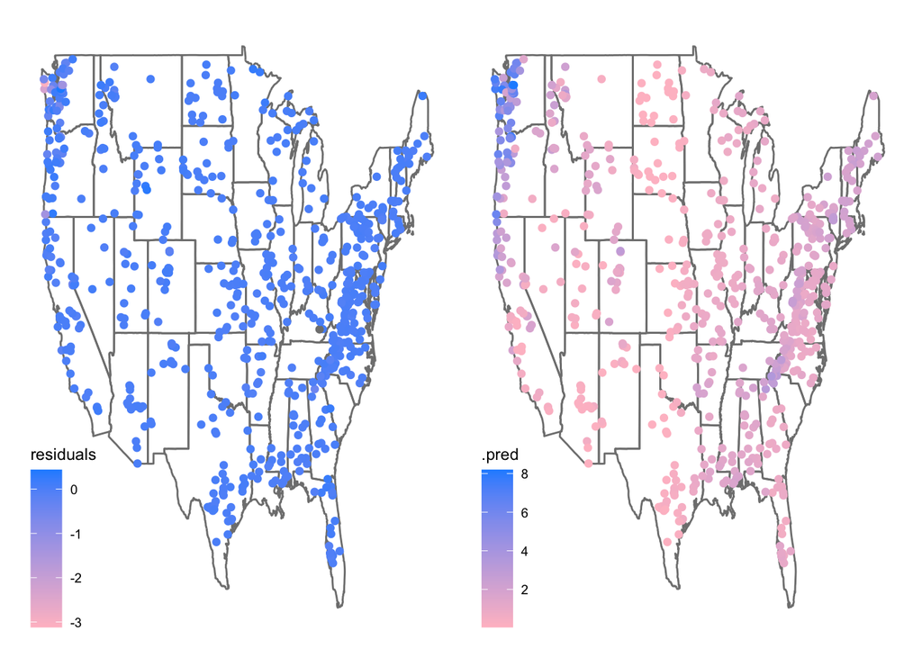

```r
# Map of Residuals
Residuals <- ggplot(data = final, aes(x = gauge_lon, y = gauge_lat)) +
  borders("state", colour = "gray50") +
  geom_point(aes(color = residuals)) +
  scale_color_gradient(low = "pink", high = "dodgerblue") +
  ggthemes::theme_map()

# Map of Predictions
Predictions <- ggplot(data = final, aes(x = gauge_lon, y = gauge_lat)) +
  borders("state", colour = "gray50") +
  geom_point(aes(color = .pred)) +
  scale_color_gradient(low = "pink", high = "dodgerblue") +
  ggthemes::theme_map()

Residuals + Predictions
```

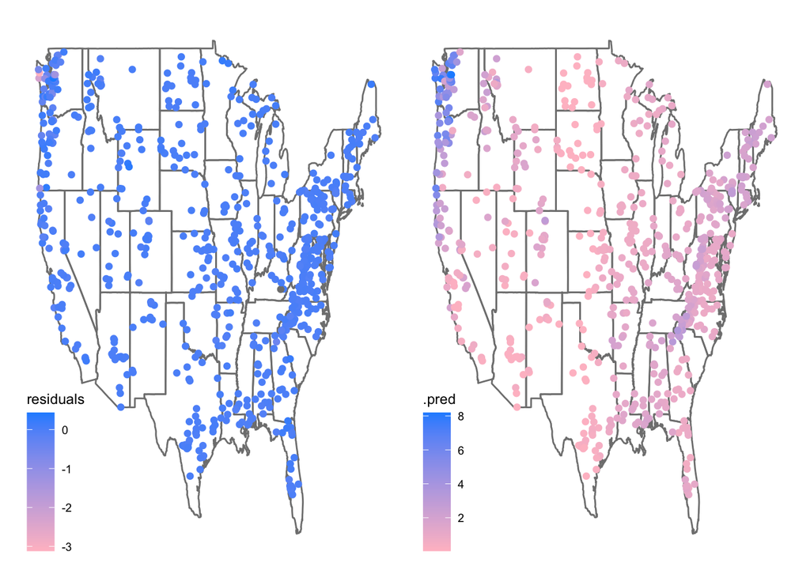

```r
combined <- Residuals + Predictions
print(combined)
```